# Linear Regression: Predicting Housing Prices in Boston

Fausto

4/27/2019

## Importing Libraries

reference: https://bigdata-madesimple.com/how-to-run-linear-regression-in-python-scikit-learn/

Ran this project in rmarkdown using `reticulate` package in R. Run the following:

```r
library(reticulate)
use_virtualenv("root") #name the enviornment from conda to use
#repl_python() #if you want to go line by line in the console
```

Now we can run python:

```python
import os
os.environ['QT_QPA_PLATFORM_PLUGIN_PATH'] = 'C:/Users/0000/Anaconda3/Library/plugins/platforms'
import numpy as np
import pandas as pd
import scipy.stats as stats
import matplotlib.pyplot as plt
import sklearn
from sklearn.datasets import load_boston
boston = load_boston()
```

Size of the data:

```python
boston.keys()
```

```
## dict_keys(['data', 'target', 'feature_names', 'DESCR', 'filename'])
```

```python
boston.data.shape
```

```
## (506, 13)
```

Features and description:

```python
print(boston.DESCR)
```

```
## .. _boston_dataset:
##
## Boston house prices dataset
## ---------------------------
##
## **Data Set Characteristics:**
##
##     :Number of Instances: 506
##
##     :Number of Attributes: 13 numeric/categorical predictive. Median Value (attribute 14) is usually the target.
##
##     :Attribute Information (in order):
##         - CRIM     per capita crime rate by town
##         - ZN       proportion of residential land zoned for lots over 25,000 sq.ft.
##         - INDUS    proportion of non-retail business acres per town
##         - CHAS     Charles River dummy variable (= 1 if tract bounds river; 0 otherwise)
##         - NOX      nitric oxides concentration (parts per 10 million)
##         - RM       average number of rooms per dwelling
##         - AGE      proportion of owner-occupied units built prior to 1940
##         - DIS      weighted distances to five Boston employment centres
##         - RAD      index of accessibility to radial highways
##         - TAX      full-value property-tax rate per $10,000
##         - PTRATIO  pupil-teacher ratio by town
##         - B        1000(Bk - 0.63)^2 where Bk is the proportion of blacks by town
##         - LSTAT    % lower status of the population
##         - MEDV     Median value of owner-occupied homes in $1000's
##
##     :Missing Attribute Values: None
##
##     :Creator: Harrison, D. and Rubinfeld, D.L.
##
## This is a copy of UCI ML housing dataset.
## https://archive.ics.uci.edu/ml/machine-learning-databases/housing/
##
##
## This dataset was taken from the StatLib library which is maintained at Carnegie Mellon University.
##
## The Boston house-price data of Harrison, D. and Rubinfeld, D.L. 'Hedonic
## prices and the demand for clean air', J. Environ. Economics & Management,
## vol.5, 81-102, 1978.   Used in Belsley, Kuh & Welsch, 'Regression diagnostics
## ...', Wiley, 1980.   N.B. Various transformations are used in the table on
## pages 244-261 of the latter.
##
## The Boston house-price data has been used in many machine learning papers that address regression
## problems.
##
## .. topic:: References
##
##    - Belsley, Kuh & Welsch, 'Regression diagnostics: Identifying Influential Data and Sources of Collinearity', Wiley, 1980. 244-261.
##    - Quinlan,R. (1993). Combining Instance-Based and Model-Based Learning. In Proceedings on the Tenth International Conference of Machine Learning, 236-243, University of Massachusetts, Amherst. Morgan Kaufmann.
```

Convert to data frame and replace column names:

```python
bos = pd.DataFrame(boston.data)
bos.head()
```

```
##         0     1     2    3      4   ...    8      9     10      11    12
## 0  0.00632  18.0  2.31  0.0  0.538  ...   1.0  296.0  15.3  396.90  4.98
## 1  0.02731   0.0  7.07  0.0  0.469  ...   2.0  242.0  17.8  396.90  9.14
## 2  0.02729   0.0  7.07  0.0  0.469  ...   2.0  242.0  17.8  392.83  4.03
## 3  0.03237   0.0  2.18  0.0  0.458  ...   3.0  222.0  18.7  394.63  2.94
## 4  0.06905   0.0  2.18  0.0  0.458  ...   3.0  222.0  18.7  396.90  5.33
##
## [5 rows x 13 columns]
```

```python
bos.columns = boston.feature_names
bos.head()
```

```
##       CRIM    ZN  INDUS  CHAS    NOX  ...    RAD    TAX  PTRATIO       B  LSTAT
## 0  0.00632  18.0   2.31   0.0  0.538  ...    1.0  296.0     15.3  396.90   4.98
## 1  0.02731   0.0   7.07   0.0  0.469  ...    2.0  242.0     17.8  396.90   9.14
## 2  0.02729   0.0   7.07   0.0  0.469  ...    2.0  242.0     17.8  392.83   4.03
## 3  0.03237   0.0   2.18   0.0  0.458  ...    3.0  222.0     18.7  394.63   2.94
## 4  0.06905   0.0   2.18   0.0  0.458  ...    3.0  222.0     18.7  396.90   5.33
##
## [5 rows x 13 columns]
```

pull out the prices and add to the dataframe:

```python
boston.target[:5]
```

```
## array([24. , 21.6, 34.7, 33.4, 36.2])
```

```python
bos['PRICE'] = boston.target
```

Use the least squares method to estimate coefficients; we drop the column we plan to predict:

```python
from sklearn.linear_model import LinearRegression
X = bos.drop('PRICE', axis = 1)

#create a linear regression object
lm = LinearRegression()
lm
```

```
## LinearRegression(copy_X=True, fit_intercept=True, n_jobs=None,
##          normalize=False)
```

Some important functions:

```r
lm.fit() -> fits a linear model

lm.predict() -> Predict Y using the linear model with estimated coefficients

lm.score() -> Returns the coefficient of determination (R^2). A measure of how well observed outcomes are replicated by the model, as the proportion of total variation of outcomes explained by the model.
```

Fit the model:

```python
lm.fit(X, bos.PRICE)
```

```
## LinearRegression(copy_X=True, fit_intercept=True, n_jobs=None,
##          normalize=False)
```

```python
print('estimated intercept coeff', lm.intercept_)
```

```
## estimated intercept coeff 36.45948838509015
```

Now construct a dataframe with the coefficients to begin predictions:

```python
pd.DataFrame(list(zip(X.columns,lm.coef_)),columns=['features','estimatedCoefficients'])
```

```
##    features  estimatedCoefficients
## 0      CRIM              -0.108011
## 1        ZN               0.046420
## 2     INDUS               0.020559
## 3      CHAS               2.686734
## 4       NOX             -17.766611
## 5        RM               3.809865
## 6       AGE               0.000692
## 7       DIS              -1.475567
## 8       RAD               0.306049
## 9       TAX              -0.012335
## 10  PTRATIO              -0.952747
## 11        B               0.009312
## 12    LSTAT              -0.524758
```

RM has a high correlation with prices as shown above. We can graph this in ggplot in R:

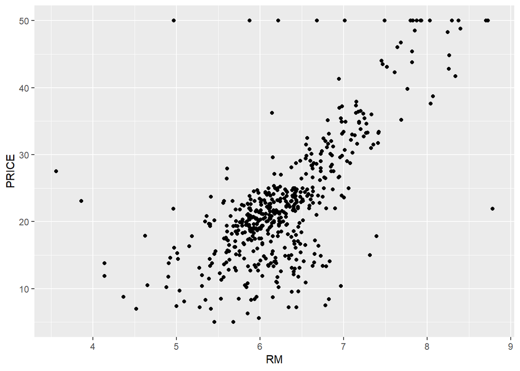

```r
rbos = py$bos
library(ggplot2)
ggplot(rbos,
       aes(RM, PRICE)) +
  geom_point()
```

we can extract a sample of the predicted prices:

```python
lm.predict(X)[0:5]
```

```
## array([30.00384338, 25.02556238, 30.56759672, 28.60703649, 27.94352423])
```

```python
predicted_values = lm.predict(X)
```

And now we can graph them to compare true to predicted:

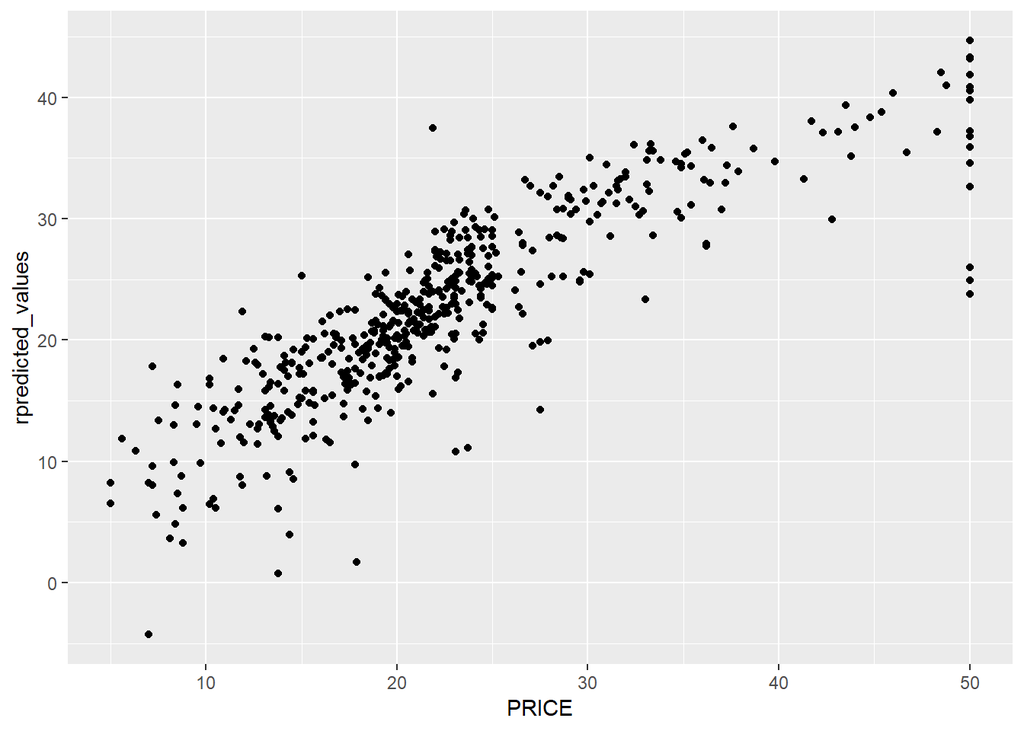

```r
rbos = py$bos #actual prices
rpredicted_values = py$predicted_values
rbos = cbind(rbos, rpredicted_values)
ggplot(rbos,
       aes(PRICE,rpredicted_values)) +
  geom_point()
```

We can calculate the mean squared error:

```python
mseFull = np.mean((bos.PRICE - lm.predict(X)) ** 2)
print(mseFull)
```

```
## 21.89483118172922
```

we can try to calculate the mean square error for one feature to see it higher:

```python
lm = LinearRegression()
lm.fit(X[['PTRATIO']], bos.PRICE)
```

```
## LinearRegression(copy_X=True, fit_intercept=True, n_jobs=None,
##          normalize=False)
```

```python
msePTRATIO = np.mean((bos.PRICE - lm.predict(X[['PTRATIO']])) ** 2)
print(msePTRATIO)
```

```
## 62.65220001376927
```

Using just this one feature is not great.

# Training and Validation

We train and test by splitting our data into random sets on both train and test so that we reduce bias in either set:

```python
X_train, X_test, Y_train, Y_test = sklearn.model_selection.train_test_split(X, bos.PRICE, test_size = 0.33, random_state = 5)
print(X_train.shape)
```

```
## (339, 13)
```

```python
print(X_test.shape)
```

```
## (167, 13)
```

```python
print(Y_train.shape)
```

```
## (339,)
```

```python
print(Y_test.shape)
```

```
## (167,)
```

build the model using the train-test data sets:

```python
lm = LinearRegression()
lm.fit(X_train, Y_train)
```

```
## LinearRegression(copy_X=True, fit_intercept=True, n_jobs=None,
##          normalize=False)
```

```python
pred_train = lm.predict(X_train)
pred_test = lm.predict(X_test)
```

```python
print("Fit a model X_train, and calculate MSE with Y_train:", np.mean((Y_train - lm.predict(X_train)) ** 2)
)
```

```
## Fit a model X_train, and calculate MSE with Y_train: 19.546758473534663
```

#Residual Plots

Residual plots are a good way to visualize the errors in your data. If you have done a good job then your data should be randomly scattered around line zero. If you see structure in your data, that means your model is not capturing some thing. Maybe be there is a interaction between 2 variables that you are not considering, or maybe you are measuring time dependent data. If you get some structure in your data, you should go back to your model and check whether you are doing a good job with your parameters:

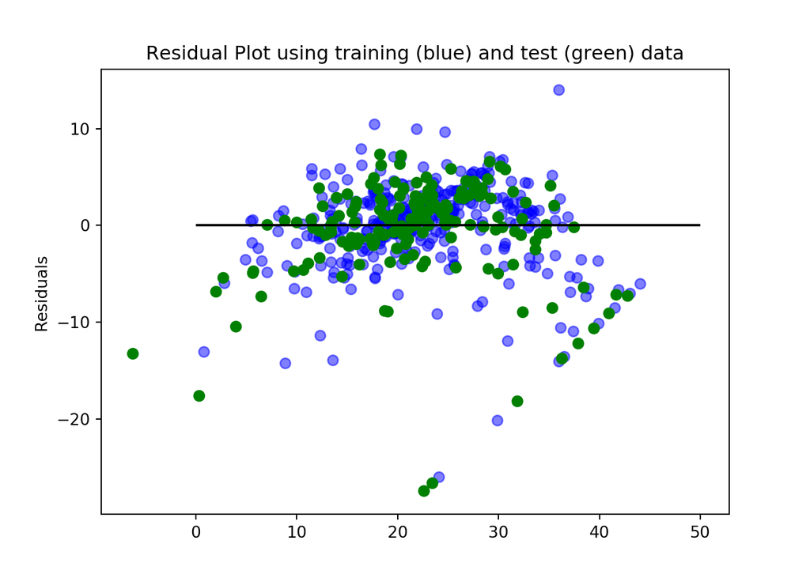

```python
plt.scatter(lm.predict(X_train), lm.predict(X_train) - Y_train, c = 'b', s = 40, alpha = .5)

plt.scatter(lm.predict(X_test), lm.predict(X_test) - Y_test, c = 'g', s = 40)

plt.hlines(y=0,xmin=0,xmax=50)
plt.title('Residual Plot using training (blue) and test (green) data')
plt.ylabel('Residuals')
```